# Fundamentos de Estadística

Por: Luis Alpizar (121369), Salvador García (119718) y Mario Rodríguez (164471)

## Examen Final

### Setup

**Inicialización:** Llamamos a todas nuestras librerías:

```r
knitr::opts_chunk$set(echo = TRUE, error = TRUE)
library(tidyverse)
library(janitor)
library(kableExtra)
library(patchwork)
library(gridExtra)
library(MASS)
library(GGally)
library(huxtable)
library(purrr)
library(data.table)
library(rsample)
library(Hmisc)
library(readr)
library(formattable)
library(foreign)
library(tidyverse)
library(usmap)
library(textshape)
library(zipcodeR)
data(zipcode)
```

### 1. Pruebas de hipótesis

De acuerdo a una encuesta en EUA, 26% de los residentes adultos de Illinois han terminado la preparatoria. Un investigador sospecha que este porcentaje es menor en un condado particular del estado. Obtiene una muestra aleatoria de dicho condado y encuentra que 69 de 310 personas en la muestra han completado la preparatoria. Estos resultados soportan su hipótesis? (describe tu elección de prueba de hipótesis, valor p y conclusión).

**Respuesta:**

Sea $p$ la proporción de adultos que han terminado la preparatoria, proponemos la siguiente prueba de hipótesis:

$H_0: p \geq 0.26$

$H_A: p < 0.26$

Aprovechando las características del estimador de proporciones (asintóticamente normal), aplicamos una prueba Wald.

```r
# Calcular los elementos de la prueba de Wald
p_hat = 69/310
ee = sqrt(p_hat * (1 - p_hat) / 310)
# prueba
w = (p_hat - 0.26)/ee
w
```

```
## [1] -1.58382
```

Estimamos el valor p a 1 cola pues buscamos demostrar que la proporción de residentes adultos de Illinois con preparatoria terminada es menor a 26%.

```r
valor_p <- (1 - pnorm(abs(w)))
valor_p * 100
```

```
## [1] 5.661737
```

Y tenemos que con 5.6% de probabilidad el valor observado de 22% parece fortuito como para sostener la hipótesis nula. Es decir, tenemos evidencia suficiente para rechazar que la proporción de residentes adultos de Illinois con preparatoria terminada es mayor o igual a 26%.

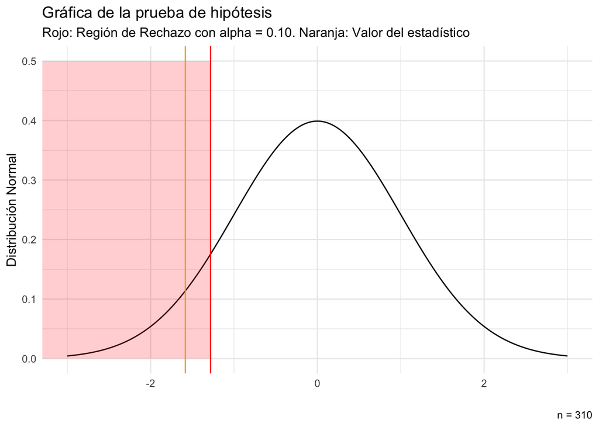

```r
ggplot(data = data.frame(x = c(-3, 3)), aes(x)) +
  stat_function(fun = dnorm, n = 310, args = list(mean = 0, sd = 1)) +
  theme_minimal() +
  labs(x = "",
       y = "Distribución Normal",
       title = "Gráfica de la prueba de hipótesis",
       subtitle = "Rojo: Región de Rechazo con alpha = 0.10. Naranja: Valor del estadístico",
       caption = "n = 310") +
  geom_vline(xintercept = -1.281552, color = "red") +
  geom_rect(aes(xmin=-Inf,xmax=-1.281552,ymin=0,ymax=.5),
            alpha=0.1,
            fill="red")+
  geom_vline(xintercept = w, color = "orange")
```

Cabe mencionar que realizamos la prueba aprovechando los resultados del Teorema Central del Límite (TCL) y la normalidad del estimador. Si realizamos la prueba con cálculo exacto tenemos que:

```r
valor_p <- pbinom(q = 69, size = 310, prob = 0.26, lower.tail = T)
valor_p * 100
```

```
## [1] 7.36073
```

La probabilidad de observar 69 (o menos) de 310 adultos con preparatoria terminada es de 7.3%, lo cual confirma el resultado de la prueba anterior. La hipótesis nula es incorrecta.

### 2. Relación entre bootstrap e inferencia bayesiana

Consideremos el caso en que tenemos una única observación $x$ proveniente de una distribución normal

$$x \sim N(\theta, 1)$$

Supongamos ahora que elegimos una distribución inicial Normal.

$$\theta \sim N(0, \tau)$$

dando lugar a la distribución posterior (como vimos en la tarea)

$$\theta|x \sim N\bigg(\frac{x}{1 + 1/\tau}, \frac{1}{1+1/\tau}\bigg)$$

Ahora, entre mayor $\tau$, más se concentra la posterior en el estimador de máxima verosimilitud $\hat{\theta}=x$. En el límite, cuando $\tau \to \infty$ obtenemos una inicial no-informativa (constante) y la distribución posterior

$$\theta|x \sim N(x,1)$$

Esta posterior coincide con la distribución de bootstrap paramétrico en que generamos valores $x^*$ de $N(x,1)$, donde $x$ es el estimador de máxima verosimilitud.

Lo anterior se cumple debido a que utilizamos un ejemplo Normal pero también se cumple aproximadamente en otros casos, lo que conlleva a una correspondencia entre el bootstrap paramétrico y la inferencia bayesiana. En este caso, la distribución bootstrap representa (aproximadamente) una distribución posterior no-informartiva del parámetro de interés. Mediante la perturbación en los datos el bootstrap aproxima el efecto bayesiano de perturbar los parámetros con la ventaja de ser más simple de implementar (en muchos casos).  
*Los detalles se pueden leer en *The Elements of Statistical Learning* de Hastie y Tibshirani.

Comparemos los métodos en otro problema con el fin de apreciar la similitud en los procedimientos:

Supongamos $x_1,...,x_n \sim N(0, \sigma^2)$, es decir, los datos provienen de una distribución con media cero y varianza desconocida.

En los puntos 2.1 y 2.2 buscamos hacer inferencia del parámetro $\sigma^2$.

**2.1 Bootstrap paramétrico.**

- Escribe la función de log-verosimilitud y calcula el estimador de máxima verosimilitud para $\sigma^2$. Supongamos que observamos los datos `x` (en la carpeta datos), ¿Cuál es tu estimación de la varianza?

**Respuesta:**

Al calcular analíticamente la función de log verosimilitud se considera la likelihood y prior de las funciones. De esta forma:

La normal sigue la siguiente distribución:
$$f(x) = \frac{1}{\sqrt{2\pi \sigma^2}} \exp\Bigg(\frac{1}{2\sigma^2}(x -\mu)^2\Bigg)$$

De manera que, dada una muestra $x_1, x_2, x_3, ..., x_n$, se puede escribir la Likelihood de la siguiente forma:

$$L(x) = \frac{1}{ ( 2\pi \sigma^2)^{n/2}} \exp(\frac{1}{2\sigma^2}\sum_i(x_i -\mu)^2)$$

Por lo tanto, usando $a = \sigma^2$ es intuitivo expresar la log-likelihood como:
$$l(x) = -\frac{n}{2} log(2\pi) - \frac{n}{2}log(\sigma^2) - \frac{1}{2\sigma^2}\sum_i (x_i-\mu)^2 \\
l(x) = -\frac{n}{2} log(2\pi) - \frac{n}{2}log(a) - \frac{1}{2a}\sum_i (x_i-\mu)^2$$
Al derivarparcialmente con respecto a $\sigma^2$ e igualando a 0, obtenemos la siguiente expresión:
$$\frac{\partial l(x)}{\partial a} = -\frac{n}{2a} - \Bigg[ \frac{1}{2}\sum_i (x_i-\mu)^2 \Bigg]\Bigg[ -\frac{1}{a^2} \Bigg] \\
-\frac{n}{2a} + \Bigg[ \frac{1}{2a^2}\sum_i (x_i-\mu)^2 \Bigg] \\
\frac{1}{2a} \Bigg[ \frac{1}{a} \sum_i (x_i-\mu)^2 - n \Bigg] = 0 \\
a = \frac{\sum_i (x_i-\mu)^2}{n}$$

De esta forma, el estimador MLE de $\sigma$ lo podemos expresar como:

$$\hat{\sigma}^2 = \frac{\sum_i (x_i-\mu)^2}{n}$$

Para encontrarla con la función optim como vimos en clase, en lugar de analíticamente, hacemos uso de la funcion crear_log_p. Esta funcion nos ayuda a generar las funciones log_p.

```r
# La función crear_log_p crea una funcion llamada log_p que recibe dos parámetros (media, sigma) tal que se estandariza la funcion y se calcula su respectiva log verosimilitud
crear_log_p <- function(x){
  log_p <- function(pars){
    media = pars[1]
    desv_est = pars[2]
    z <- (x - media) / desv_est
    log_verosim <- -(log(desv_est) +  0.5 * mean(z^2))
    log_verosim
  }
  log_p
}
```

Con esto procedemos a cargar los datos y optimizarlo con la función optim:

```r
load("data/x.RData")
muestra <- x

var_sesgada <- sum((x-mean(x))^2)/length(x)
var_insesgada <- sum((x-mean(x))^2)/(length(x)-1)
var(x)
```

```
## [1] 131.8516
```

```r
log_p <- crear_log_p(muestra)

res <-
  optim(
    par = c(0, 0.5),
    fn = log_p,
    control = list(fnscale = -1, maxit = 10000),
    method = "Nelder-Mead"
    )

est_mle <-
  dplyr::tibble(
    parametro = c("media", "sigma"),
    estimador = res$par
    ) %>%
  textshape::column_to_rownames("parametro")
```

Al comparar el estimador que calculamos analíticamente con el proporcionado con la función optim, vemos que solamente hay una diferencia de:

```r
sqrt(var_sesgada)-res$par[2]
```

```
## [1] 0.007658511
```

Cuando se usa función *var* de R, nos toma la segunda forma que es la versión insesgada. Pero en este ejemplo, nosotros estaremos ocupando la primera debido a que es el que tenemos como resultado del MLE.

** Aproxima el error estándar de la estimación usando **bootstrap paramétrico** y realiza un histograma de las replicaciones bootstrap.**

Para el aproximar el error estándar usando boostrap paramétrico hacemos uso de las funciones generadas en clase (con sus respectivas modificaciones)

```r
# simular_modelo encuentra n número de observaciones de una distribución normal con la media y sigma proporcionada
simular_modelo <- function(n, media, sigma){
  rnorm(n, media, sigma)
}
```

```r
# la función rep_boot repite
rep_boot <- function(rep, crear_log_p, est_mle, n){
  muestra_bootstrap <-
    simular_modelo(
      n = length(muestra),
      media = est_mle["media", "estimador"],
      sigma = est_mle["sigma", "estimador"]
      )

  log_p_boot <- crear_log_p(muestra_bootstrap)

  # optimizamos

  res_boot <-
    optim(
      par = c(0, 0.5),
      fn = log_p_boot,
      control = list(fnscale = -1, maxit = 1000),
      method = "Nelder-Mead"
      )

  try(if(res_boot$convergence != 0) stop("No se alcanzó convergencia."))
  tibble(parametro = c("media", "sigma"), estimador_boot = res_boot$par)
}
```

```r
reps_boot <- purrr::map_dfr(
  .x = 1:5000,
  .f = ~ rep_boot(.x, crear_log_p, est_mle, n = length(muestra)),
  rep = ".id"
  )

reps_boot %>% nrow()
```

```
## [1] 10000
```

```r
error_est <-
  reps_boot %>%
  group_by(parametro) %>%
  summarise(ee_boot = sd(estimador_boot))
bind_cols(est_mle, error_est) %>%
  mutate(across(where(is.numeric), round, 3)) %>%
  dplyr::select(parametro, estimador, ee_boot)
```

| parametro | estimador | ee_boot |
| --- | --- | --- |
| media | 0.56 | 0.921 |
| sigma | 11.4 | 0.657 |

Mostrando el histograma tanto de sigma como de la media:

[figure not shown]

```r
reps_boot %>%
  ggplot2::ggplot(aes(x = estimador_boot)) +
  geom_histogram(aes(fill = parametro), alpha = .8)+
  facet_wrap(~parametro, scales = "free")+
  theme_minimal()+
  labs(
    title = "Histograma de mu y sigma",
    subtitle = "La gráfica muestra la distibución de las replicaciones con bootstrap paramétrico",
    caption = "Se toman en cuenta 10,000 replicaciones bootstrap",
    y = "Número de replicaciones",
    x = "Valor del estimador boostrap",
    fill = "Parámetro"
      )+
  theme(legend.position = "bottom")+
  scale_fill_manual(values = c("gray40", "dodgerblue4"))
```

- Aproxima el error estándar de la estimación usando **bootstrap paramétrico** y realiza un histograma de las replicaciones bootstrap.

**2.2 Análisis bayesiano**

- Continuamos con el problema de hacer inferencia de $\sigma^2$. Comienza especificando una inicial Gamma Inversa, justifica tu elección de los parámetros de la distribución inicial y grafica la función de densidad.

**Respuesta:**

- 2.2.1 Comienza especificando una inicial Gamma Inversa, justifica tu elección de los parámetros de la distribución inicial y grafica la función de densidad.

La distribución de la pregunta, es adaptable al modelo de Gamma-Inverso
$$X_i\sim \mathsf{N}(\mu, \sigma)$$
donde Queremos estimar μ y σ.

Previo a iniciar el análisis Bayesiano, al igual que en el inciso anterior, observamos los datos de x de forma que tengamos noción del tipo de datos que vamos a describir y que variables queremos estimar. Se observa que los datos están, en efecto, distribuidos de una forma similar a una normal.

```r
data(x)
sd(x)
```

```
## [1] 11.48266
```

```r
Hmisc::describe(x)
```

```
## x
##        n  missing distinct     Info     Mean      Gmd      .05      .10
##      150        0      150        1   0.5643    13.02  -20.545  -14.296
##      .25      .50      .75      .90      .95
##   -7.186    1.293    8.210   15.046   18.940
##
## lowest : -28.42246 -26.77889 -24.49067 -23.48753 -21.94367
## highest:  21.72504  23.09265  25.32958  26.42585  26.86348
```

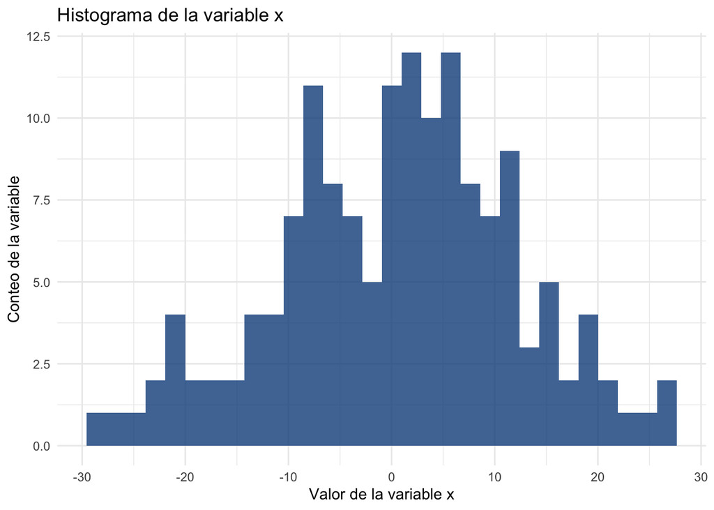

```r
x %>%
  data.frame() %>%
  set_names("x") %>%
  ggplot()+
  geom_histogram(aes(x = x), fill = "dodgerblue4", alpha = .8)+
  theme_minimal() +
  labs(x = "Valor de la variable x",
       y = "Conteo de la variable",
       title = "Histograma de la variable x")+
  theme(legend.position = "bottom")
```

**Cálculo de Iniciales**

De la misma forma que en los ejemplos de clase, comenzamos con $\sigma^2$ y efectuamos una simulación para verificar nuestra inicial.

```r
# Inferimos un valor de la desviación estándar basado en la observación realizada
sigma_0 <- 10
# seleccionamos valor que genere una dispersión adecuada
a <- 5
b <- a * sigma_0^2
c(a = a, b = b)
```

```
##   a   b
##   5 500
```

```r
#Se simula y calculan cuartiles:

tau <- rgamma(1000, a, b)
quantile(tau, c(0.05, 0.95))
```

```
##          5%         95%
## 0.003862535 0.018308683
```

Utilizando la información del problema definimos el rango en el que con alta probabilidad se encuentra la media poblacional y ajustamos n_0:

```r
mu_0 <- 0 #distribución con media cero
n_0 <- 3.5 # ajustamos concentración en la inicial después de algunas simulaciones
tau <- rgamma(1000, a,b)
sigma <- 1/sqrt(tau)
mu <- map_dbl(sigma, ~ rnorm(1, mu_0, .x / sqrt(n_0)))
quantile(mu, c(0.05, 0.5, 0.95))
```

```
##         5%        50%        95%
## -9.2752539  0.4651985 10.2348744
```

Simulamos una normal inversa utilizando la función de las notas y plasmamos líneas de referencia de -10 y 10:

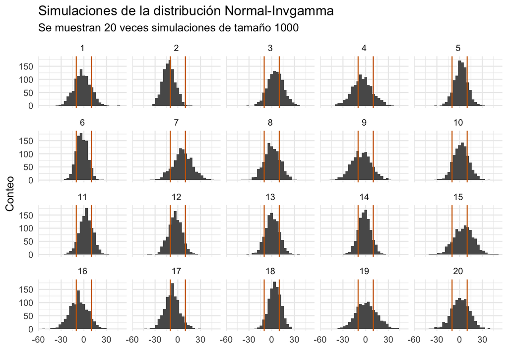

```r
simular_normal_invgamma <- function(n, pars){
  mu_0 <- pars[1]
  n_0 <- pars[2]
  a <- pars[3]
  b <- pars[4]
  # simular media
  tau <- rgamma(1, a, b)
  sigma <- 1 / sqrt(tau)
  mu <- rnorm(1, mu_0, sigma/sqrt(n_0))
  # simular sigma
  rnorm(n, mu, sigma)
}

set.seed(2021)
sims_tbl <- tibble(rep = 1:20) %>%
  mutate(valor_x = map(rep, ~ simular_normal_invgamma(1000, c(mu_0, n_0, a, b)))) %>%
  unnest(cols = c(valor_x))
ggplot(sims_tbl, aes(x = valor_x)) + geom_histogram() +
  facet_wrap(~ rep) +
  geom_vline(xintercept = c(-10, 10), colour = "darkorange3")+
  theme_minimal()+
  labs(title = "Simulaciones de la distribución Normal-Invgamma",
       subtitle = "Se muestran 20 veces simulaciones de tamaño 1000",
       x = "",
       y = "Conteo")
```

Observamos simulaciones mayoritariamente adecuadas conforme al espacio de posibilidades.

**Cálculo de Posteriores**

- 2.2.2 Calcula analíticamente la distribución posterior.

Basado en Gamma Inversa y conforme a la pregunta la posterior es

$\tau|x$ es representado por $\mathsf{Gamma}(\alpha', \beta')$ donde $\alpha' = \alpha + n/2$ y
$$\beta' = \beta + \frac{1}{2}\sum_{i=1}^{n}(x_{i} - \bar{x})^2 + \frac{nn_0}{n+n_0}\frac{({\bar{x}}-\mu_{0})^2}{2}$$

De la misma forma para $\mu|\sigma$,x es normal con media $\mu' = \frac{n_0\mu_{0}+n{\bar{x}}}{n_0 +n}$ y varianza $\sigma^2/({n_0 +n})$ resultando lo anterior en:
$$p(\mu,\sigma|x) = p(\mu|x,\sigma)p(\sigma|x)$$

Dicho lo anterior, generamos la función posterior, aplicada a los datos de x:

```r
calcular_pars_posterior <- function(x, pars_inicial){
  # iniciales
  mu_0 <- pars_inicial[1]
  n_0 <- pars_inicial[2]
  a_0 <- pars_inicial[3]
  b_0 <- pars_inicial[4]
  # muestra
  n <- length(x)
  media <- mean(x)
  S2 <- sum((x - media)^2)
  # sigma post
  a_1 <- a_0 + 0.5 * n
  b_1 <- b_0 + 0.5 * S2 + 0.5 * (n * n_0) / (n + n_0) * (media - mu_0)^2
  # posterior mu
  mu_1 <- (n_0 * mu_0 + n * media) / (n + n_0)
  n_1 <- n + n_0
  c(mu_1, n_1, a_1, b_1)
}
pars_posterior <- calcular_pars_posterior(x, c(mu_0, n_0, a, b))
pars_posterior
```

```
## [1] 5.514058e-01 1.535000e+02 8.000000e+01 1.032349e+04
```

Y comprobamos consistencia entre la posterior y la inicial:

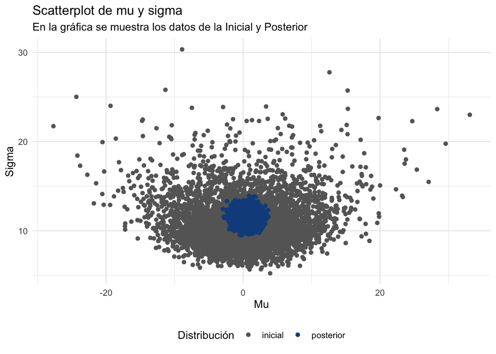

```r
sim_params <- function(m, pars){
  mu_0 <- pars[1]
  n_0 <- pars[2]
  a <- pars[3]
  b <- pars[4]
  # simular sigmas
  sims <- tibble(tau = rgamma(m, a, b)) %>%
    mutate(sigma = 1 / sqrt(tau))
  # simular mu
  sims <- sims %>% mutate(mu = rnorm(m, mu_0, sigma / sqrt(n_0)))
  sims
}
sims_inicial <- sim_params(5000, c(mu_0, n_0, a, b)) %>%
  mutate(dist = "inicial")
sims_posterior <- sim_params(5000, pars_posterior) %>%
  mutate(dist = "posterior")
sims <- bind_rows(sims_inicial, sims_posterior)
ggplot(sims, aes(x = mu, y = sigma, colour = dist)) +
  geom_point()+
  theme_minimal()+
  theme(legend.position = "bottom")+
  labs(y = "Sigma",
        x = "Mu",
        title = "Scatterplot de mu y sigma",
       subtitle = "En la gráfica se muestra los datos de la Inicial y Posterior",
       color = "Distribución"
       )+
  scale_color_manual(values = c("gray40", "dodgerblue4"))
```

Se observa que la posterior es consistente con la información inicial.

2.2.3 Realiza un histograma de simulaciones de la distribución posterior y calcula el error estándar de la distribución.

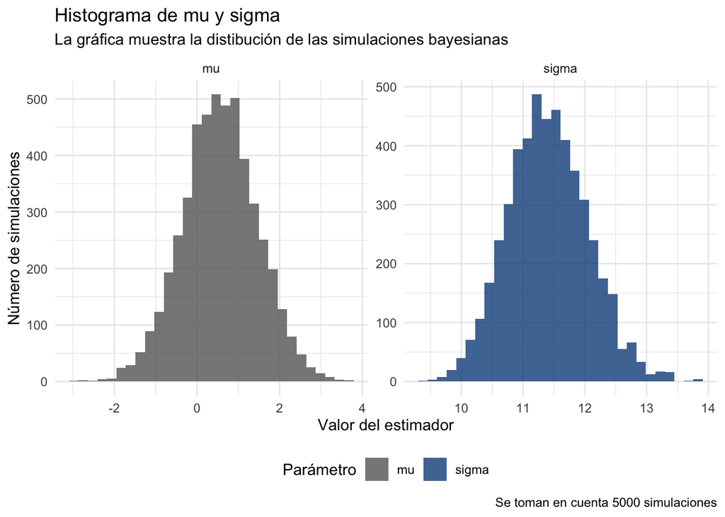

```r
sims_posterior %>%
  gather(variable, valor, tau:mu) %>%
  filter(variable != "tau") %>%
  ggplot(aes(x = valor))+
  geom_histogram(aes(fill = variable), alpha = 0.8)+
  facet_wrap(~variable, scales = "free")+
  theme_minimal()+
  theme(legend.position = "bottom")+
  scale_fill_manual(values = c("gray40", "dodgerblue4"))+
   labs(
    title = "Histograma de mu y sigma",
    subtitle = "La gráfica muestra la distibución de las simulaciones bayesianas",
    caption = "Se toman en cuenta 5000 simulaciones",
    y = "Número de simulaciones",
    x = "Valor del estimador",
    fill = "Parámetro"
      )
```

Simulamos muestras tamaño 10 y calculamos medias posteriores:

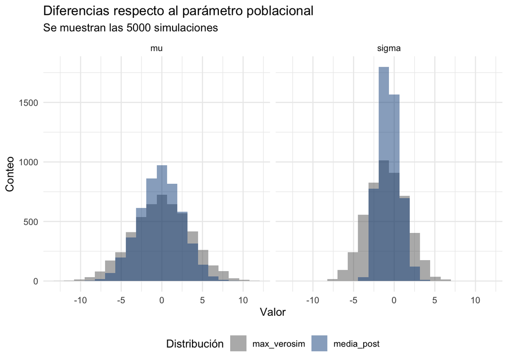

```r
#Convertimos los datos x a dataFrame para facilidad de manipulación con dplyr
set_x <- as.data.frame(x)

simular_muestra <- function(rep, mu_0, n_0, a_0, b_0){
  muestra_set_x<- set_x %>%
    sample_n(10, replace = FALSE)
  pars_posterior <- calcular_pars_posterior(muestra_set_x$x,
                                            c(mu_0, n_0, a_0, b_0))

  medias_post <-
    sim_params(1000, pars_posterior) %>%
    summarise(across(everything(), mean)) %>%
    dplyr::select(mu, sigma)
  media <- mean(muestra_set_x$x)
  est_mv <- c("mu" = media,
              "sigma" = sqrt(mean((muestra_set_x$x - media)^2)))
  bind_rows(medias_post, est_mv) %>%
    mutate(rep = rep, tipo = c("media_post", "max_verosim")) %>%
    pivot_longer(mu:sigma, names_to = "parametro", values_to = "estimador")
}

#Obtenemos Mu y Sigma de la población de los datos x
poblacion <- set_x %>%
  summarise(mu = mean(set_x$x), sigma = sd(set_x$x)) %>%
  pivot_longer(mu:sigma, names_to = "parametro", values_to = "valor_pob")

#Calculamos y Graficamos los errores
errores <- map(1:5000, ~ simular_muestra(.x, mu_0, n_0, a, b)) %>%
  bind_rows() %>% left_join(poblacion) %>%
  mutate(error = (estimador - valor_pob))
ggplot(errores, aes(x = error, fill = tipo)) +
  geom_histogram(bins = 20, position = "identity", alpha = 0.5) +
  facet_wrap(~parametro)+
  theme_minimal()+
  theme(legend.position = "bottom")+
  labs(
    title = "Diferencias respecto al parámetro poblacional",
    subtitle = "Se muestran las 5000 simulaciones",
    x = "Valor",
    y = "Conteo",
    fill = "Distribución"
  )+
  scale_fill_manual(values = c("gray40", "dodgerblue4"))
```

Imprimimos los errores:

```r
errores %>%
  group_by(tipo, parametro) %>%
  summarise(recm = sqrt(mean(error^2)) %>% round(2)) %>%
  arrange(parametro)
```

```
## # A tibble: 4 x 3
## # Groups:   tipo [2]
##   tipo        parametro  recm
##   <chr>       <chr>     <dbl>
## 1 max_verosim mu         3.53
## 2 media_post  mu         2.62
## 3 max_verosim sigma      2.56
## 4 media_post  sigma      1.4
```

La estimación de la desviación estándar del modelo es superior a la de máxima verosimilitud. Tomando como base el error cuadrático medio, se muestra que los estimadores de la media superior son mejores.

- 2.2.4 ¿Cómo se comparan tus resultados con los de bootstrap paramétrico?

Los resultados de la media y sigma en bootstrap paramétrico comparados con las distribuciones posteriores del análisis son bastante similares en forma, escala y uniformidad de los datos.

**2.3 Supongamos que ahora buscamos hacer inferencia del parámetro** $\tau=log(\sigma)$, ¿cuál es el estimador de máxima verosimilitud?

- Utiliza bootstrap paramétrico para generar un intervalo de confianza del 95% para el parámetro $\tau$ y realiza un histograma de las replicaciones bootstrap.

**Respuesta:**

Al calcular analíticamente la función de log verosimilitud se considera la likelihood y prior de las funciones. De esta forma:

La normal sigue la siguiente distribución con su respectiva likelihood:
$$f(x) = \frac{1}{\sqrt{2\pi \sigma^2}} \exp\Bigg(\frac{1}{2\sigma^2}(x -\mu)^2\Bigg) \\
L(x) = \frac{1}{ ( 2\pi \sigma^2)^{n/2}} \exp(\frac{1}{2\sigma^2}\sum_i(x_i -\mu)^2)$$

De manera que, dada una muestra $x_1, x_2, x_3, ..., x_n$, y substituyendo $a = log(\sigma)$ de tal forma que $\sigma^2 = e^{2a}$ tenemos que la log likelihood la podemos expresar de la siguiente manera:
$$l(x) = -\frac{n}{2} log(2\pi) - \frac{n}{2}log(e^{2log \sigma}) - \frac{1}{2 e^{2 log \sigma}}\sum_i (x_i-\mu)^2 \\
l(x) = -\frac{n}{2} log(2\pi) - \frac{n}{2}log(e^{2a}) - \frac{1}{2e^{2a}}\sum_i (x_i-\mu)^2$$
Al derivar parcialmente con respecto $a$ e igualando a 0, obtenemos la siguiente expresión:
$$\frac{\partial l(x)}{\partial a} = - \frac{n 2 e^{2a}}{2 e^{2a}} - \Bigg[ \frac{1}{2}\sum_i (x_i-\mu)^2 \Bigg]\Bigg[ -\frac{2}{e^{2a}} \Bigg] \\
= -n + \Bigg[ \frac{1}{e^{2a}}\sum_i (x_i-\mu)^2 \Bigg] \\
\Rightarrow \Bigg[ \frac{1}{e^{2a}}\sum_i (x_i-\mu)^2 \Bigg] = n\\
\Rightarrow \frac{\sum_i (x_i-\mu)^2}{{n}} = e^{2a}\\
\Rightarrow \frac{\sum_i (x_i-\mu)^2}{{n}} = e^{2a}\\
\Rightarrow a = \log{\sqrt{\frac{\sum_i (x_i-\mu)^2}{n}}}\\$$
Como $a = log(\sigma)$, entonces tenemos que $\hat{log(\sigma)} = \log{\sqrt{\frac{\sum_i (x_i-\mu)^2}{n}}}$ siendo el último el estimador MLE.

Este resultado es congruente con la propiedad de los MLE vista en clase, en particular el teorema de equivarianza de los MLE:

Sea $\tau = g(\theta)$ una función de $\theta$ bien comportada. Entonces si $\hat{\theta_n}$ es el MLE de $\theta$, entonces $\hat{\tau_n} = g(\hat{\theta_n})$ es el MLE de $\tau$, ya que aplicando directamente el teorema obtenemos el mismo resultado.

Para encontrarla con la función *optim* como vimos en clase, en lugar de analíticamente, hacemos uso de la funcion crear_log_p. Esta funcion nos ayuda a generar las funciones log_p.

```r
# La función crear_log_p crea una funcion llamada log_p que recibe dos parámetros (media, sigma) tal que se estandariza la funcion y se calcula su respectiva log verosimilitud
crear_log_p <- function(x){
  log_p <- function(pars){
    media = pars[1]
    log_sigma = pars[2]
    z <- (x - media) / exp(log_sigma)
    log_verosim <- -(log_sigma +  0.5 * mean(z^2))
    log_verosim
  }
  log_p
}
```

Con esto procedemos a cargar los datos y optimizarlo con la función optim:

```r
load("data/x.RData")
muestra <- x

log_p <- crear_log_p(muestra)

res <-
  optim(
    par = c(0, 0.5),
    fn = log_p,
    control = list(fnscale = -1, maxit = 10000),
    method = "Nelder-Mead"
    )

est_mle <-
  tibble(
    parametro = c("media", "log-sigma"),
    estimador = res$par
    )

est_mle
```

| parametro | estimador |
| --- | --- |
| media | 0.561 |
| log-sigma | 2.44 |

al compararlo con el resultado anterior (es decir, el de sigma sin la transformación) tenemos que es equivalente a aplicar el logaritmo a $\sigma$. Para el aproximar el error estándar usando boostrap paramétrico hacemos uso de las funciones generadas en clase (con sus respectivas modificaciones)

```r
# simular_modelo encuentra n número de observaciones de una distribución normal con la media y sigma proporcionada
simular_modelo <- function(n, media, log_sigma){
  rnorm(n, media, exp(log_sigma))
}
```

```r
# la función rep_boot repite
rep_boot <- function(rep, crear_log_p, est_mle, n){
  muestra_bootstrap <-
    simular_modelo(
      n = length(muestra),
      media = est_mle["media", "estimador"],
      log_sigma = est_mle["log-sigma", "estimador"]
      )

  log_p_boot <- crear_log_p(muestra_bootstrap)

  # optimizamos

  res_boot <-
    optim(
      par = c(0, 0.5),
      fn = log_p_boot,
      control = list(fnscale = -1, maxit = 1000),
      method = "Nelder-Mead"
      )

  try(if(res_boot$convergence != 0) stop("No se alcanzó convergencia."))
  tibble(parametro = c("media", "log-sigma"), estimador_boot = res_boot$par)
}
```

```r
est_mle <- est_mle %>%
  column_to_rownames("parametro")

reps_boot <- map_dfr(
  .x = 1:5000,
  .f = ~ rep_boot(.x, crear_log_p, est_mle, n = length(muestra)),
  rep = ".id"
  )

reps_boot %>% nrow()
```

```
## [1] 10000
```

```r
error_est <-
  reps_boot %>%
  group_by(parametro) %>%
  summarise(ee_boot = sd(estimador_boot))
bind_cols(est_mle, error_est) %>%
  mutate(across(where(is.numeric), round, 3)) %>%
  dplyr::select(parametro, estimador, ee_boot)
```

[output not shown]

Mostrando el histograma tanto de sigma como de la media:

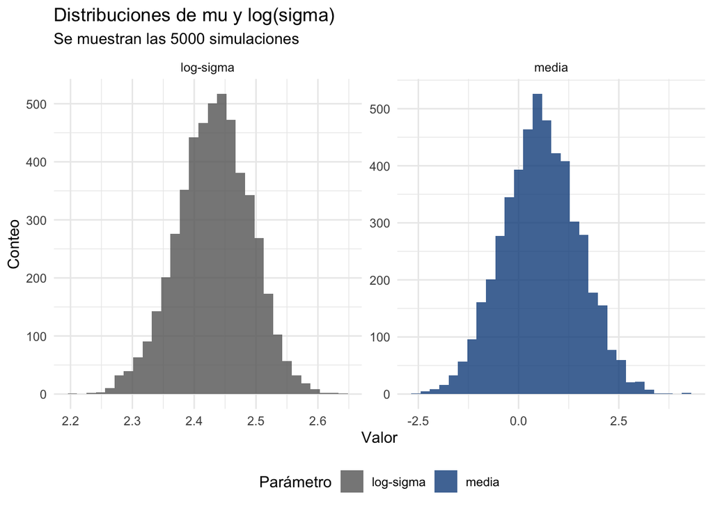

```r
reps_boot %>%
  ggplot(aes(x = estimador_boot)) +
  geom_histogram(aes(fill = parametro), alpha = 0.8) +
  facet_wrap(~parametro, scales = "free")+
  theme_minimal()+
  theme(legend.position = "bottom")+
  labs(
    title = "Distribuciones de mu y log(sigma)",
    subtitle = "Se muestran las 5000 simulaciones",
    x = "Valor",
    y = "Conteo",
    fill = "Parámetro"
  )+
  scale_fill_manual(values = c("gray40", "dodgerblue4"))
```

### 3. Bayesiana y regularización

Lee el ejempo *2.7 Informative prior distribution for cancer rates* del libro [Bayesian Data Analysis](http://www.stat.columbia.edu/~gelman/book/BDA3.pdf) (página 46).

En el siguiente ejercicio harás algo similar al ejemplo anterior, en este caso con el modelo Beta-Binomial.

Los datos *pew_research_center_june_elect_wknd_data.dta* tienen información de ecnuestas realizadas durante la campaña presidencial 2008 de EUA.

**Respuesta:**

```r
# leer los datos, utilizar el codigo zip para obtener los estados. Drop de las
# columnas que no vamos a ocupar
original_data <- foreign::read.dta('./data/pew_research_center_june_elect_wknd_data.dta') %>%
  dplyr::select(c("ideo", "zipcode"))

# obtener estados y código FIPS para usar en plot_usmap
mydata <- merge(x = original_data, y = zipcode, by.x = "zipcode", by.y = "zip", all.x = T)
mydata$fips <- usmap::fips(mydata$state)

# filtrar sin Alaska, Hawai, DC, y las fuerzas del pacífico y europa (AP y AE)
mydata <- mydata %>% filter(state != "AK" & state != "HI" & state != "DC" & state != "AE" & state != "AP")

glimpse(mydata)
```

```
## Rows: 29,727
## Columns: 7
## $ zipcode   <chr> "01001", "01007", "01007", "01010", "01010", "01013", "0101…
## $ ideo      <fct> moderate, liberal, liberal, moderate, moderate, conservativ…
## $ city      <chr> "Agawam", "Belchertown", "Belchertown", "Brimfield", "Brimf…
## $ state     <chr> "MA", "MA", "MA", "MA", "MA", "MA", "MA", "MA", "MA", "MA",…
## $ latitude  <dbl> 42.07061, 42.27842, 42.27842, 42.12604, 42.12604, 42.16149,…
## $ longitude <dbl> -72.62029, -72.41100, -72.41100, -72.20552, -72.20552, -72.…
## $ fips      <chr> "25", "25", "25", "25", "25", "25", "25", "25", "25", "25",…
```

Tenemos distintas categorías para la clase `ideología`. En particular, estamos interesados en aquellos que se consideran “very liberal”.

```r
table(mydata$ideo)
```

```
##
## missing/not asked very conservative      conservative          moderate
##                 0              2312              9415             10755
##           liberal      very liberal        dk/refused
##              4388              1397              1091
```

- Estima el porcentaje de la población de cada estado (excluyendo Alaska, Hawai, y DC) que se considera *very liberal*, utilizando el estimador de máxima verosimilitud.

```r
# agrupamos población encuestada por estado
poll_nj <- mydata %>% group_by(state, fips) %>%
  summarise(pob = n())
# agrupamos población very liberal por estado
poll_ideo_nj <- mydata %>%
  group_by(state, ideo) %>%
  summarise(success = n()) %>%
  filter(ideo == "very liberal")
# mezclamos las tablas y sacar MLE por estado
state_poll_gral <- left_join(x=poll_nj, y=poll_ideo_nj) %>% dplyr::select(-c("ideo"))
state_poll_gral[is.na(state_poll_gral)] <- 0
state_poll_gral <- state_poll_gral %>% mutate(p_mle = success/pob)
state_poll_gral
```

```
## # A tibble: 48 x 5
## # Groups:   state [48]
##    state fips    pob success  p_mle
##    <chr> <chr> <int>   <int>  <dbl>
##  1 AL    01      597      26 0.0436
##  2 AR    05      292       7 0.0240
##  3 AZ    04      526      27 0.0513
##  4 CA    06     2713     174 0.0641
##  5 CO    08      455      27 0.0593
##  6 CT    09      373      12 0.0322
##  7 DE    10      113       7 0.0619
##  8 FL    12     1662      62 0.0373
##  9 GA    13      982      42 0.0428
## 10 IA    19      420      17 0.0405
## # … with 38 more rows
```

- Grafica en el eje *x* el número de encuestas para cada estado y en el eje *y* la estimación de máxima verosimilitud. ¿Qué observas?

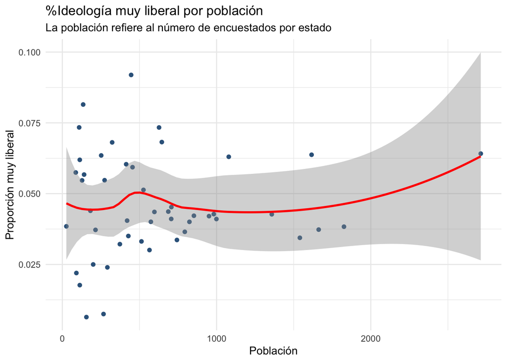

```r
ggplot(data = state_poll_gral, aes(x = pob, y = p_mle)) +
  geom_point(color = "steelblue4") +
  #theme(legend.position = "none") +
  geom_smooth(color= "red") +
  xlab("Población") +
  ylab("Proporción muy liberal") +
  labs(title = "%Ideología muy liberal por población", subtitle = "La población refiere al número de encuestados por estado") +
  theme_minimal()
```

Observamos que los estados donde la proporción de ideología muy liberal es alta parecen tener tanto población chica como grande. Lo anterior se puede apreciar un poco en el siguiente mapa donde vemos que estados chicos como `Vermont`, `South Dakota`, `Rhode Island`, y estados grandes como `California`, `New York`, `Illinois` (en términos poblacionales) tienen proporción alta de esta ideología.

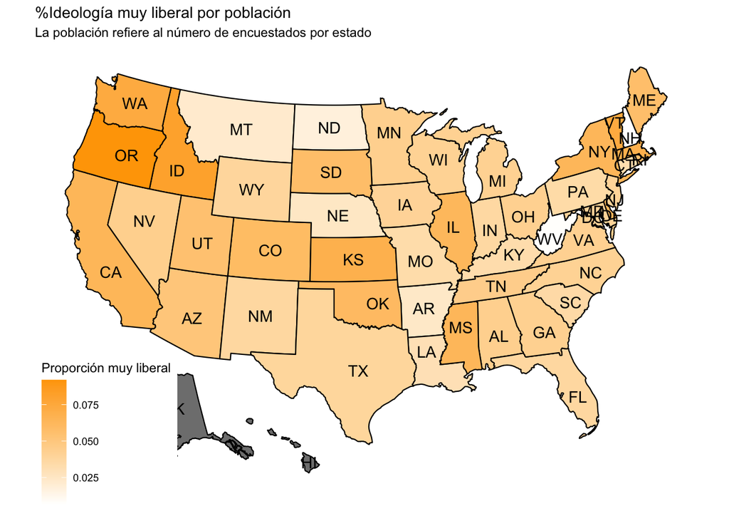

```r
# graficamos con mapa de EEUU la proporción de muy liberales
states_us <- state_poll_gral %>% ungroup() %>% dplyr::select(fips, p_mle)
usmap::plot_usmap(data=states_us, values = "p_mle", labels = T) +
  scale_fill_continuous(name = "Proporción muy liberal", low = "white", high = "orange") +
  #theme(legend.position = "right") +
  labs(title = "%Ideología muy liberal por población",
       subtitle = "La población refiere al número de encuestados por estado")
```

- Grafica en el eje *x* el porcentaje de votos que obtuvo Obama en la elección para cada estado y en el eje *y* la estimación de máxima verosimilitud. ¿Qué observas? (usa los datos *2008ElectionResult.csv*)

```r
# Leer los datos y asignar FIPS
elections2008 <- read.csv("./data/2008ElectionResult.csv") %>%
  filter(state != "Alaska" & state != "Hawaii" & state != "District of Columbia") %>%
  mutate(state_abb = state.abb[match(state, state.name)]) %>%
  dplyr::select(c("state_abb", "vote_Obama_pct"))
elections2008$fips <- usmap::fips(elections2008$state_abb)
colnames(elections2008) <- c("state", "Obama_pct", "fips")

# Combinamos con nuestra tabla
elections2008 <- left_join(elections2008, state_poll_gral, copy = T)
```

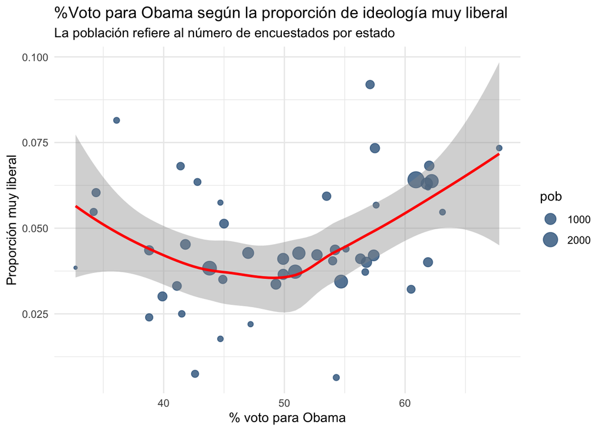

```r
ggplot(data = elections2008, aes(x = Obama_pct, y = p_mle)) +
  geom_point(aes(size = pob), color = "steelblue4", alpha = 0.8) +
  geom_smooth(color= "red") +
  xlab("% voto para Obama") +
  ylab("Proporción muy liberal") +
  labs(title = "%Voto para Obama según la proporción de ideología muy liberal", subtitle = "La población refiere al número de encuestados por estado") +
  theme_minimal()
```

Ahora vemos que el voto para Obama tuvo variaciones importantes, fue muy bajo y muy alto para estados que se consideraban “muy liberal”. Esto debido a que la cantidad de encuestados por estado es muy diferente. De manera similar, los mismos estados que mencionamos previamente con población chica y grande fueron votantes de Obama.

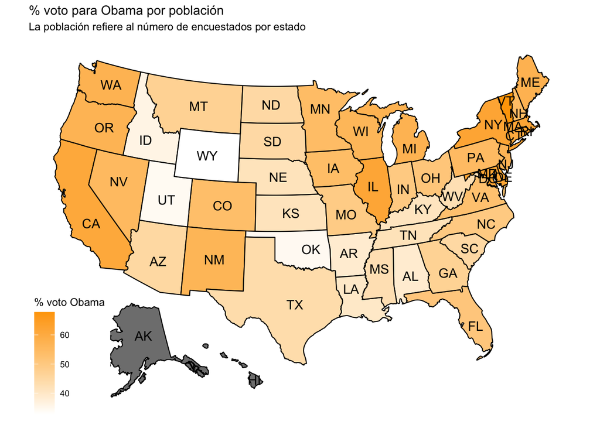

```r
usmap::plot_usmap(data=elections2008, values = "Obama_pct", labels = T) +
  scale_fill_continuous(name = "% voto Obama", low = "white", high = "orange") +
  #theme(legend.position = "right") +
  labs(title = "% voto para Obama por población",
       subtitle = "La población refiere al número de encuestados por estado")
```

- Estima el mismo porcentaje usando inferencia bayesiana, en particular la familia conjugada binomial-beta. Deberás estimar la proporción de manera independiente para cada estado, sin embargo, utilizarás la misma inicial a lo largo de todos.
- Para elegir los parámetros $\alpha$, $\beta$ de la incial considera la media y varianza de la distribución predictiva posterior (que en este caso tiene distribución [Beta-Binomial](https://en.wikipedia.org/wiki/Beta-binomial_distribution)) y empata la media y varianza observadas a sus valores observados para después depejar $\alpha$ y $\beta$ (puedes usar [Wolframalpha](https://www.wolframalpha.com/) para resolver).

De la distribución Beta sabemos que:

$$E(X) = \frac{\alpha}{\alpha + \beta }$$

$$V(X) = \frac{\alpha \beta}{(\alpha + \beta)^2 + (\alpha + \beta + 1)}$$

*Nota: Lo correcto sería calcular $E[\frac{X_j}{n_j}]$ y $V[\frac{X_j}{n_j}]$

```r
# Empatar primer y segundo momento de la Beta con la media y varianza
# observada en los datos para calcular alfa y beta
mu_obs <- mean(state_poll_gral$p_mle)
var_obs <- var(state_poll_gral$p_mle)
tibble(mu_obs, var_obs)
```

| mu_obs | var_obs |
| --- | --- |
| 0.0459 | 0.000321 |

```r
#n_full <- sum(state_poll_gral$pob)
#n_very_liberal <- sum(state_poll_gral$success)
#tibble(n_full, n_very_liberal, mu_obs, var_obs)

# De wolfram-alpha, la prior para p_j ~ Beta(a,b) tiene parámetros
alfa = 6
beta = 129
```

- Utiliza la media posterior de cada estado como estimador puntual y repite las gráficas del inciso anterior.

```r
# Usamos la posterior para p_j|X ~ Beta(a + k_j, n_j - k_j + b)
# calculamos la media posterior de cada estado
mu_posterior = function(nj, kj){
  alfa = alfa + kj
  beta = nj - kj + beta
  alfa/(alfa+beta)
}
pj_bayes <- mapply(FUN = mu_posterior, state_poll_gral$pob, state_poll_gral$success)

# Agregamos la predicción a las tablas
state_poll_gral$p_bayes <- pj_bayes
elections2008$p_bayes <- pj_bayes
```

**Nota:** Este proceso para obtener los parámetros de la incial es razonable para este ejercicio, sin embargo, un modelo jerárquico sería la manera de formalizar este acercamiento y se estudiará en próximas materias.

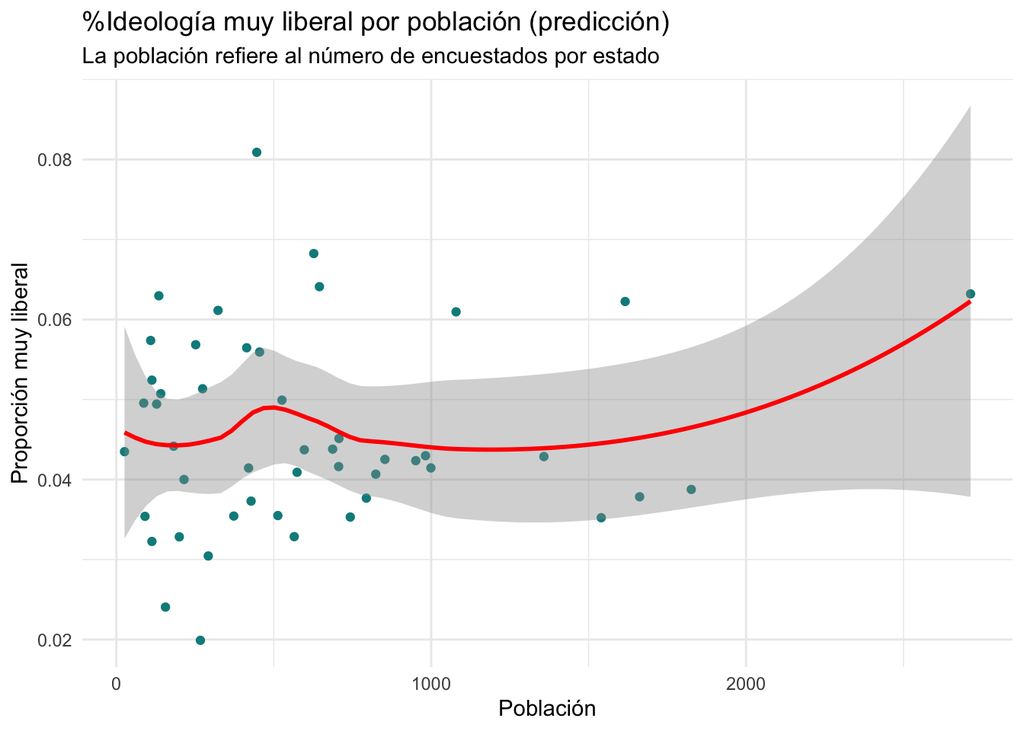

```r
# gráfica de proporciones
ggplot(data = state_poll_gral, aes(x = pob, y = p_bayes)) +
  geom_point(color = "darkcyan") +
  #theme(legend.position = "none") +
  geom_smooth(color= "red") +
  xlab("Población") +
  ylab("Proporción muy liberal") +
  labs(title = "%Ideología muy liberal por población (predicción)", subtitle = "La población refiere al número de encuestados por estado") +
  theme_minimal()
```

[figure not shown]

```r
# gráfica porcentaje de voto
ggplot(data = elections2008, aes(x = Obama_pct, y = p_bayes)) +
  geom_point(aes(size = pob), color = "darkcyan", alpha = 0.8) +
  geom_smooth(color = "red") +
  xlab("% voto para Obama") +
  ylab("Proporción muy liberal") +
  labs(title = "%Voto para Obama según la proporción de ideología muy liberal (predicción)", subtitle = "La población refiere al número de encuestados por estado") +
  theme_minimal()
```